# Independent Samples t-Test

ChatGPT 4o

2025-01-22

独立样本t检验（Independent Samples t-Test）起源于威廉·戈塞特（William Gosset）的研究，他以笔名“Student”发表了t分布相关的文章，因此t检验也被称为“Student’s t-test”。独立样本t检验最初用于啤酒酿造中的质量控制，目的是比较不同配方或生产条件下的啤酒质量是否存在显著差异。随着时间的推移，这种检验方法被广泛应用于各个科学领域，用于比较两个独立样本的均值差异。

# 1 原理

独立样本t检验（Independent Samples t-Test）是一种用于比较两个独立样本之间均值差异的统计方法，目的是判断两个样本是否来自均值相等的总体。独立样本t检验基于均值差异的大小与样本数据的变异性，结合t分布来进行假设检验，其结果可以用于推断两个总体是否具有显著性差异。

## 1.1 检验步骤

独立样本t检验主要依据以下步骤进行：

### 1.1.1 提出假设

1. 提出原假设和备择假设：
- **原假设 ($H_0$)**：两组总体均值相等，即 $\mu_1 = \mu_2$。
- **备择假设 ($H_1$)**：两组总体均值不相等，即 $\mu_1 \neq \mu_2$（双尾检验）。

### 1.1.2 计算t值

2. 计算t值：
   - t值的计算公式是两个样本均值之差除以均值差的标准误，其公式为：
     $$t = \frac{\bar{X}_1 - \bar{X}_2}{\sqrt{\frac{s_1^2}{n_1} +
     \frac{s_2^2}{n_2}}}$$
     其中：
- $\bar{X}_1, \bar{X}_2$：两组样本的均值；
- $s_1^2, s_2^2$：两组样本的方差；
- $n_1, n_2$：两组样本的大小。

### 1.1.3 查找临界值

3. 查找t分布的临界值：
   - 根据显著性水平（通常为0.05）和自由度，从t分布表中查找临界值，判断是否拒绝原假设。

假设两组样本方差相等时，自由度为：
$$df = n_1 + n_2 - 2$$
若方差不相等（Welch 检验），自由度根据 Welch-Satterthwaite 方程计算。

### 1.1.4 结论判断

4. 结论判断：
   - 如果计算得到的t值大于临界值，或者p值小于显著性水平，则拒绝原假设，认为两个组之间存在显著性差异。

## 1.2 假设条件

独立样本t检验的假设包括： - 数据是从正态分布中抽取的。 - 两组数据之间相互独立。 - 两组的方差相等（方差齐性假设）。

# 2 适用范围

独立样本t检验适用于以下场景：

## 2.1 独立组比较

- 两个样本之间没有重叠，互为独立。例如，不同地区的居民、男性和女性、实验组和对照组。

## 2.2 连续变量

- 待比较的变量是定量的，并且通常需要服从正态分布，例如体重、身高、成绩等。

## 2.3 两组水平

- 因变量具有两个分类水平，例如新药与安慰剂、两种教学法的比较。

## 2.4 方差齐性

- 虽然t检验有稳健性，即在一定程度上对方差不齐较为宽容，但在理想情况下应满足方差齐性假设。

# 3 应用情境

独立样本t检验被广泛应用于医学、心理学、教育学及社会科学等领域，以下为一些常见的应用情境：

## 3.1 医学研究

- 比较两种不同药物治疗效果的差异。例如，研究新药与对照药物对降低血压的效果是否存在显著差异。

## 3.2 教育研究

- 评估不同教学方法对学生学习成绩的影响。例如，传统课堂教学和在线课程教学对学生考试成绩的影响。

## 3.3 市场调研

- 研究两种促销手段对客户购买行为的影响。例如，比较电视广告与社交媒体广告对销售量的影响。

## 3.4 社会心理学

- 比较不同群体的态度差异。例如，城市居民与农村居民在环境保护态度上的差异。

# 4 优缺点

## 4.1 优点

- **操作简单**：独立样本t检验的计算相对简单，只需知道两个样本的均值、标准差及样本量，即可进行统计推断。
- **推论明确**：通过t值和p值可以明确判断两个组之间是否存在显著差异，结论一目了然。
- **适用性强**：适用于许多实际研究情境，特别是对两个组进行均值差异比较的场合。

## 4.2 缺点

- **假设严格**：独立样本t检验对正态性和方差齐性假设较为敏感。如果样本数据不服从正态分布或方差不齐，可能会导致结果不可靠。
- **只适用于两组比较**：独立样本t检验仅能处理两组数据之间的比较，不能处理多组数据的情况。如果需要比较三组或以上的均值，需要使用单因素方差分析（ANOVA）。
- **对异常值敏感**：t检验对异常值较为敏感，异常值可能对均值和标准差产生较大影响，进而影响t值的计算和检验结果。

# 5 在R中的实现及结果解释

在R语言中，`t.test()`函数可以实现独立样本t检验。下面是一个具体的例子：

```r
# 假设我们有两个独立样本的数据，分别存储在变量group1和group2中
group1 <- c(5.1, 4.9, 6.3, 5.8, 5.4, 5.0, 6.1)
group2 <- c(6.5, 7.2, 6.8, 7.0, 6.9, 7.3, 7.1)

# 使用t.test()函数进行独立样本t检验
t_test_result <- t.test(group1, group2, var.equal = TRUE)

# 输出结果
print(t_test_result)
```

```
##
##  Two Sample t-test
##
## data:  group1 and group2
## t = -6.2229, df = 12, p-value = 4.431e-05
## alternative hypothesis: true difference in means is not equal to 0
## 95 percent confidence interval:
##  -1.9673291 -0.9469566
## sample estimates:
## mean of x mean of y
##  5.514286  6.971429
```

```r
summary(t_test_result)
```

```
##             Length Class  Mode
## statistic   1      -none- numeric
## parameter   1      -none- numeric
## p.value     1      -none- numeric
## conf.int    2      -none- numeric
## estimate    2      -none- numeric
## null.value  1      -none- numeric
## stderr      1      -none- numeric
## alternative 1      -none- character
## method      1      -none- character
## data.name   1      -none- character
```

```r
str(t_test_result)
```

```
## List of 10
##  $ statistic  : Named num -6.22
##   ..- attr(*, "names")= chr "t"
##  $ parameter  : Named num 12
##   ..- attr(*, "names")= chr "df"
##  $ p.value    : num 4.43e-05
##  $ conf.int   : num [1:2] -1.967 -0.947
##   ..- attr(*, "conf.level")= num 0.95
##  $ estimate   : Named num [1:2] 5.51 6.97
##   ..- attr(*, "names")= chr [1:2] "mean of x" "mean of y"
##  $ null.value : Named num 0
##   ..- attr(*, "names")= chr "difference in means"
##  $ stderr     : num 0.234
##  $ alternative: chr "two.sided"
##  $ method     : chr " Two Sample t-test"
##  $ data.name  : chr "group1 and group2"
##  - attr(*, "class")= chr "htest"
```

```r
t_test_result$method
```

```
## [1] " Two Sample t-test"
```

```r
t_test_result$data.name
```

```
## [1] "group1 and group2"
```

```r
t_test_result$null.value
```

```
## difference in means
##                   0
```

```r
t_test_result$alternative
```

```
## [1] "two.sided"
```

```r
t_test_result$estimate
```

```
## mean of x mean of y
##  5.514286  6.971429
```

```r
t_test_result$stderr
```

```
## [1] 0.2341579
```

```r
t_test_result$statistic
```

```
##         t
## -6.222907
```

```r
t_test_result$parameter
```

```
## df
## 12
```

```r
t_test_result$p.value
```

```
## [1] 4.431094e-05
```

```r
t_test_result$conf.int
```

```
## [1] -1.9673291 -0.9469566
## attr(,"conf.level")
## [1] 0.95
```

```r
t_test_result$conf.int[1]
```

```
## [1] -1.967329
```

```r
t_test_result$conf.int[2]
```

```
## [1] -0.9469566
```

```r
t_test_result2 <- t.test(group1, group2, var.equal = TRUE, conf.level = 0.99)
t_test_result2
```

```
##
##  Two Sample t-test
##
## data:  group1 and group2
## t = -6.2229, df = 12, p-value = 4.431e-05
## alternative hypothesis: true difference in means is not equal to 0
## 99 percent confidence interval:
##  -2.1723875 -0.7418982
## sample estimates:
## mean of x mean of y
##  5.514286  6.971429
```

在以上代码中：

- `t.test()`函数用于执行独立样本t检验。
- `var.equal = TRUE`表示假设两组方差相等。如果不确定方差齐性，可以将`var.equal`设为`FALSE`，此时函数将自动应用Welch校正，以应对方差不等的情况。
- `group1`和`group2`是两个独立组的样本数据，分别代表两组被测量的变量值。
- `conf.level`用于设置置信水平，默认为0.95，可以根据需要调整。

## 5.1 结果解释

- **t值（t statistic）**：描述两个组均值差异相对于数据变异性的大小，t值越大表示均值差异越显著。
- **自由度（df）**：用于确定t分布的形状，自由度由两个样本量决定，自由度的计算公式为 df = n1 + n2 - 2。
- **p值（p-value）**：用于判断是否拒绝原假设。如果p值小于设定的显著性水平（通常为0.05），说明两个组均值存在显著差异。
- **置信区间（confidence interval）**：表示两个组均值差异的置信区间，如果置信区间不包含0，则说明均值差异显著。
- **样本均值**：包含两个组的样本均值，方便比较两组数值上的差异。

## 5.2 等价方法（长型数据格式）

```r
# 将数据转换长型、数据框格式
library(ggplot2)
data <- data.frame(
  value = c(group1, group2),
  group = factor(c(rep("Group 1", length(group1)), rep("Group 2", length(group2))))
)
head(data)
```

```
##   value   group
## 1   5.1 Group 1
## 2   4.9 Group 1
## 3   6.3 Group 1
## 4   5.8 Group 1
## 5   5.4 Group 1
## 6   5.0 Group 1
```

```r
tail(data)
```

```
##    value   group
## 9    7.2 Group 2
## 10   6.8 Group 2
## 11   7.0 Group 2
## 12   6.9 Group 2
## 13   7.3 Group 2
## 14   7.1 Group 2
```

```r
ttest.result <- t.test(value ~ group, data, var.equal = TRUE)
ttest.result
```

```
##
##  Two Sample t-test
##
## data:  value by group
## t = -6.2229, df = 12, p-value = 4.431e-05
## alternative hypothesis: true difference in means between group Group 1 and group Group 2 is not equal to 0
## 95 percent confidence interval:
##  -1.9673291 -0.9469566
## sample estimates:
## mean in group Group 1 mean in group Group 2
##              5.514286              6.971429
```

```r
summary(ttest.result)
```

```
##             Length Class  Mode
## statistic   1      -none- numeric
## parameter   1      -none- numeric
## p.value     1      -none- numeric
## conf.int    2      -none- numeric
## estimate    2      -none- numeric
## null.value  1      -none- numeric
## stderr      1      -none- numeric
## alternative 1      -none- character
## method      1      -none- character
## data.name   1      -none- character
```

```r
str(ttest.result)
```

```
## List of 10
##  $ statistic  : Named num -6.22
##   ..- attr(*, "names")= chr "t"
##  $ parameter  : Named num 12
##   ..- attr(*, "names")= chr "df"
##  $ p.value    : num 4.43e-05
##  $ conf.int   : num [1:2] -1.967 -0.947
##   ..- attr(*, "conf.level")= num 0.95
##  $ estimate   : Named num [1:2] 5.51 6.97
##   ..- attr(*, "names")= chr [1:2] "mean in group Group 1" "mean in group Group 2"
##  $ null.value : Named num 0
##   ..- attr(*, "names")= chr "difference in means between group Group 1 and group Group 2"
##  $ stderr     : num 0.234
##  $ alternative: chr "two.sided"
##  $ method     : chr " Two Sample t-test"
##  $ data.name  : chr "value by group"
##  - attr(*, "class")= chr "htest"
```

```r
# 方差分析ANOVA
aov_result <- aov(value ~ group, data = data)
aov_result
```

```
## Call:
##    aov(formula = value ~ group, data = data)
##
## Terms:
##                    group Residuals
## Sum of Squares  7.431429  2.302857
## Deg. of Freedom        1        12
##
## Residual standard error: 0.4380694
## Estimated effects may be unbalanced
```

```r
summary(aov_result)
```

```
##             Df Sum Sq Mean Sq F value   Pr(>F)
## group        1  7.431   7.431   38.73 4.43e-05 ***
## Residuals   12  2.303   0.192
## ---
## Signif. codes:  0 '***' 0.001 '**' 0.01 '*' 0.05 '.' 0.1 ' ' 1
```

```r
str(aov_result)
```

[output not shown]

```r
coef(aov_result)
```

```
##  (Intercept) groupGroup 2
##     5.514286     1.457143
```

```r
TukeyHSD(aov_result)
```

```
##   Tukey multiple comparisons of means
##     95% family-wise confidence level
##
## Fit: aov(formula = value ~ group, data = data)
##
## $group
##                     diff       lwr      upr    p adj
## Group 2-Group 1 1.457143 0.9469566 1.967329 4.43e-05
```

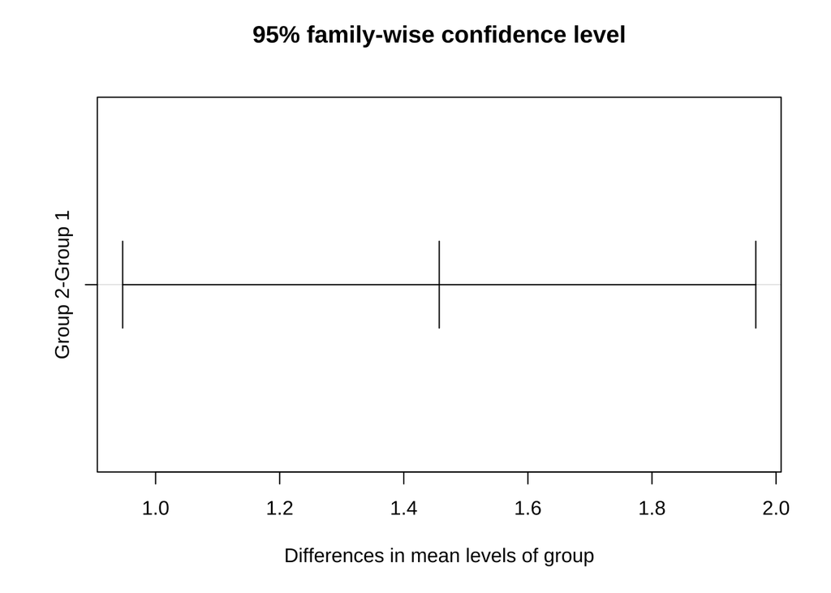

```r
plot(TukeyHSD(aov_result))
```

```r
# 一般线性模型General Linear Model
lm_result <- lm(value ~ group, data = data)
lm_result
```

```
##
## Call:
## lm(formula = value ~ group, data = data)
##
## Coefficients:
##  (Intercept)  groupGroup 2
##        5.514         1.457
```

```r
summary(lm_result)
```

```
##
## Call:
## lm(formula = value ~ group, data = data)
##
## Residuals:
##      Min       1Q   Median       3Q      Max
## -0.61429 -0.35357 -0.02143  0.27143  0.78571
##
## Coefficients:
##              Estimate Std. Error t value Pr(>|t|)
## (Intercept)    5.5143     0.1656  33.304 3.41e-13 ***
## groupGroup 2   1.4571     0.2342   6.223 4.43e-05 ***
## ---
## Signif. codes:  0 '***' 0.001 '**' 0.01 '*' 0.05 '.' 0.1 ' ' 1
##
## Residual standard error: 0.4381 on 12 degrees of freedom
## Multiple R-squared:  0.7634, Adjusted R-squared:  0.7437
## F-statistic: 38.72 on 1 and 12 DF,  p-value: 4.431e-05
```

```r
str(lm_result)
```

[output not shown]

```r
coef(lm_result)
```

```
##  (Intercept) groupGroup 2
##     5.514286     1.457143
```

```r
anova(lm_result)
```

```
## Analysis of Variance Table
##
## Response: value
##           Df Sum Sq Mean Sq F value    Pr(>F)
## group      1 7.4314  7.4314  38.725 4.431e-05 ***
## Residuals 12 2.3029  0.1919
## ---
## Signif. codes:  0 '***' 0.001 '**' 0.01 '*' 0.05 '.' 0.1 ' ' 1
```

## 5.3 数据的可视化

为了更好地理解两个独立样本之间的均值差异，可以通过数据的可视化来呈现差异性。以下是如何在R中使用箱线图和均值柱状图来可视化这两个组的数据：

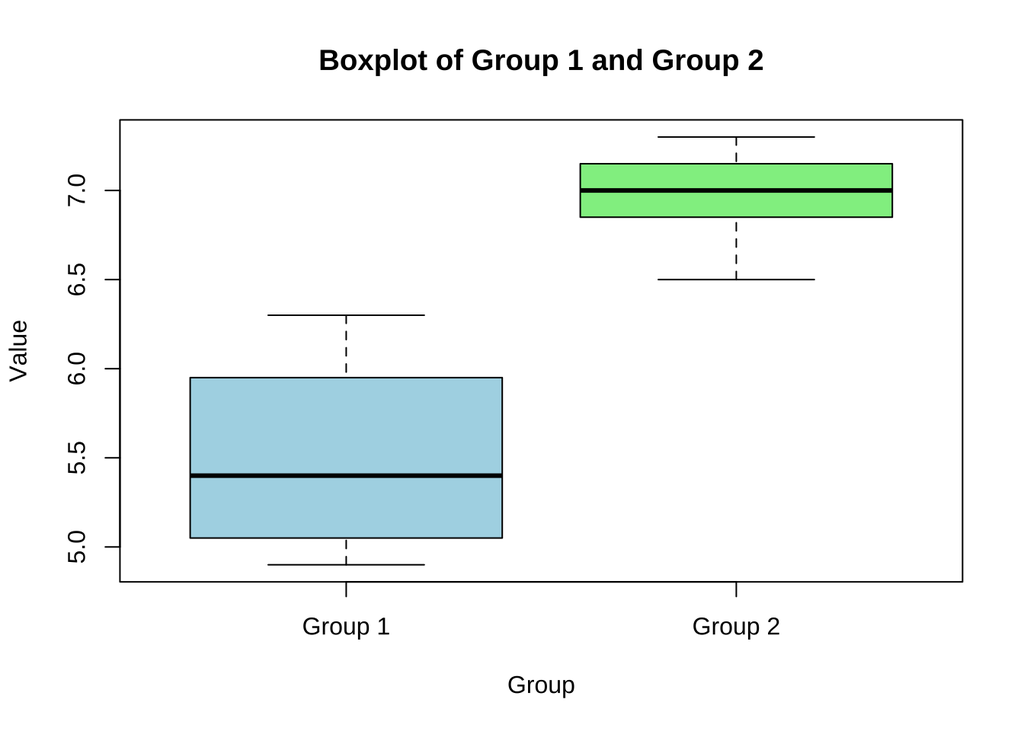

```r
# 使用箱线图可视化两组数据的分布
boxplot(group1, group2,
        col = c("lightblue", "lightgreen"),
        names = c("Group 1", "Group 2"),
        main = "Boxplot of Group 1 and Group 2",
        xlab = "Group", ylab = "Value")
```

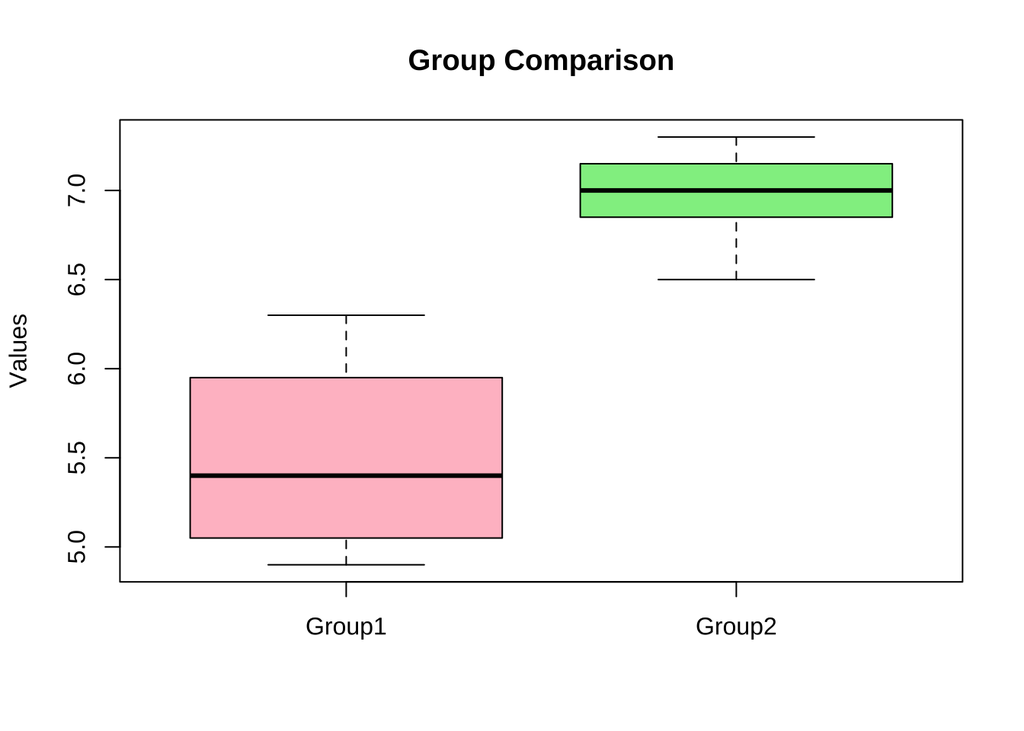

```r
data_list <- list(Group1 = group1, Group2 = group2)
boxplot(data_list,
        col = c("pink", "lightgreen"),
        main = "Group Comparison",
        ylab = "Values")
```

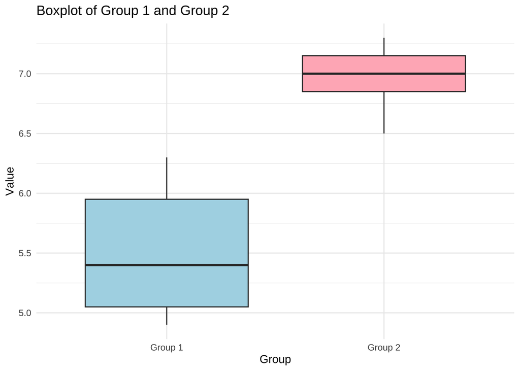

```r
ggplot(data, aes(x = group, y = value)) +
  geom_boxplot(fill = c("lightblue","lightpink")) +
  theme_minimal() +
  labs(title = "Boxplot of Group 1 and Group 2", x = "Group", y = "Value")
```

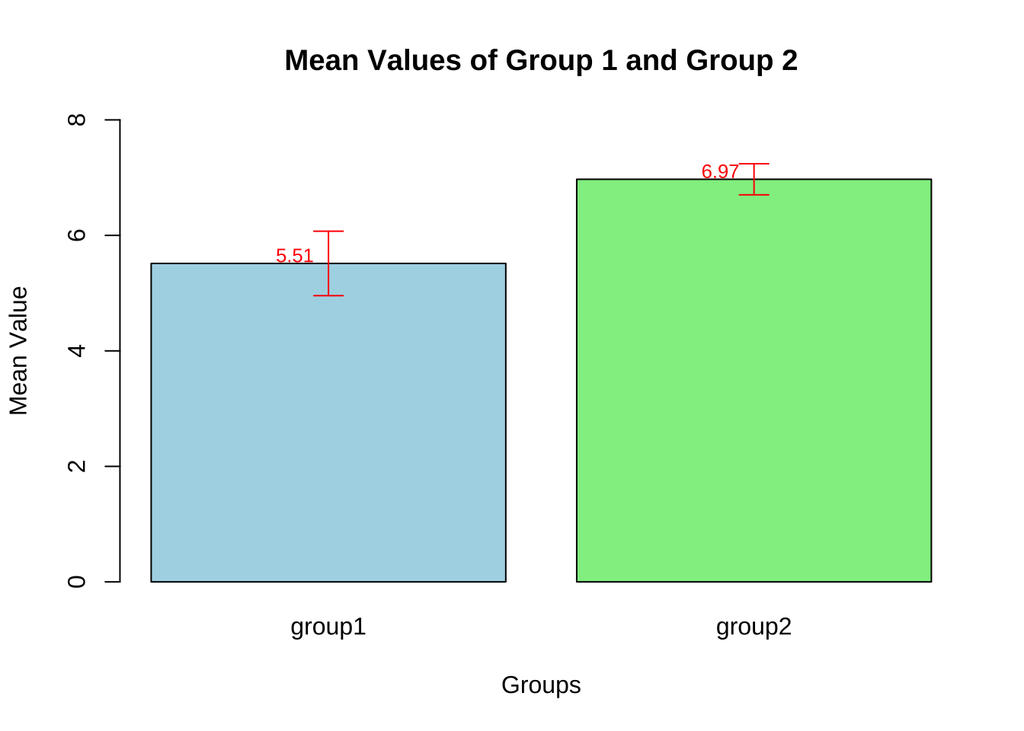

```r
# 使用均值柱状图可视化两组数据的均值
means <- c(mean(group1), mean(group2))
sds <- c(sd(group1), sd(group2))
bar_error <- barplot(means,
        names.arg = c("group1","group2"),
        col = c("lightblue", "lightgreen"),
        main = "Mean Values of Group 1 and Group 2",
        xlab = "Groups",
        ylab = "Mean Value",
        ylim = c(0, 8)
        )
# 添加误差条
arrows(bar_error, means - sds, bar_error, means + sds, angle = 90, code = 3, length = 0.1, col = "red")
# 在柱状图顶部添加均值标签
text(bar_error, means + 0.1, labels = round(means, 2), pos = 2, cex = 0.8, col = "red")
```

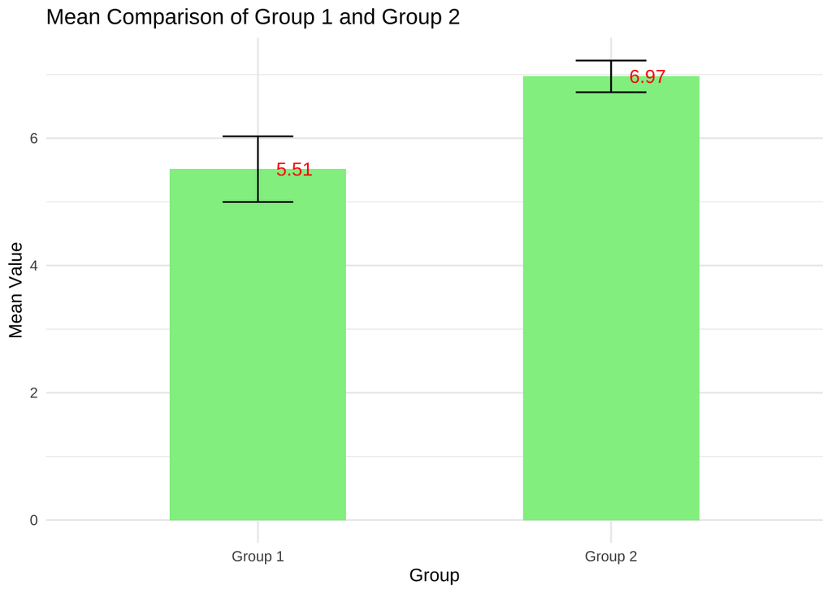

```r
ggplot(data, aes(x = group, y = value)) +
  stat_summary(fun = mean, geom = "bar", fill = "lightgreen", width = 0.5) +
  stat_summary(fun.data = mean_cl_normal, geom = "errorbar", width = 0.2) +
  stat_summary(fun = mean, geom = "text", aes(label = round(after_stat(y), 2)),
               hjust = -0.5, color = "red", size = 4) +  # 在均值点右方添加文本
  theme_minimal() +
  labs(title = "Mean Comparison of Group 1 and Group 2", x = "Group", y = "Mean Value")
```

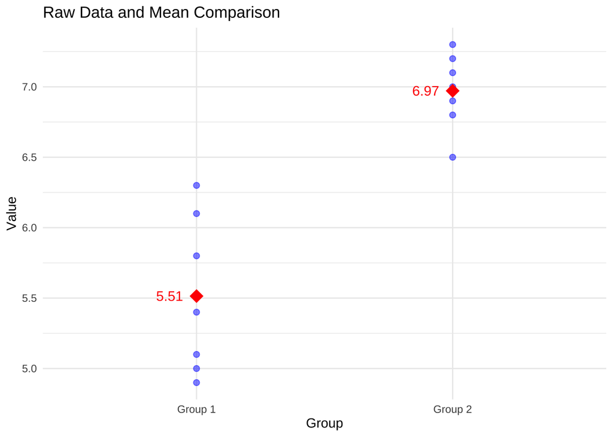

```r
# 同时呈现原始数据点及统计结果(均值)
ggplot(data, aes(x = group, y = value)) +
  geom_point(size = 2, alpha = 0.5, color ="blue") +
  stat_summary(fun = mean, geom = "point", shape = 18, size = 5, color = "red") +
  stat_summary(fun = mean, geom = "text", aes(label = round(after_stat(y), 2)),
               hjust = 1.5, color = "red", size = 4) +  # 在均值点左方添加文本
  theme_minimal() +
  labs(title = "Raw Data and Mean Comparison", x = "Group", y = "Value")
```

在以上代码中：

  注意，`stat_summary(fun.data = mean_cl_normal, geom = "errorbar", width = 0.2)` 假设数据是正态分布的。建议先验证数据是否符合正态性，如果数据不符合，可以考虑使用非参数方法。

# 6 小结

- 独立样本t检验是一种常用的统计方法，用于判断两个独立组之间的均值差异是否具有显著性。
- 通过t值和p值来判断两个样本是否来自相同的总体，广泛应用于医学、教育、社会科学等领域。
- 独立样本t检验易于实施，但对正态性和方差齐性假设较为敏感。
- 在使用时应确保数据符合这些假设，或选择稳健的替代方法。
- 在R中，`t.test()`函数可方便地实现独立样本t检验，并通过直观的统计量帮助研究者做出推断。
- 可视化手段（如箱线图和均值柱状图）能够更加清晰地展示两组数据之间的差异。